# Practical Homework 2: Support Vector Machines

Erdenetuya Namsrai

2025-05-02

# 1. Data Preparation

1.1 Load Libraries

```r
library(e1071)
library(caret)
library(tidyverse)
library(dplyr)
library(ggplot2)
library(tidyr)
library(gridExtra)
library(ROSE)
library(DMwR2)
library(smotefamily)
library(corrplot)
library(readr)
library(tibble)
library(yardstick)
library(forcats)
```

1.2 Load Dataset and Perform Data Preparation

```r
data <- read.csv("D:\\Data Science Master in USA\\Spring_2025\\DATA 5322 Statistical Machine Learning II\\Homework\\Practical Homework 2_Support Vector Machines\\nhis_2022.csv")

df_nhis <- data
dim(df_nhis)
```

```
## [1] 35115    48
```

```r
head(df_nhis, 3)
```

```
##   YEAR SERIAL STRATA PSU        NHISHID REGION PERNUM          NHISPID     HHX
## 1 2022      1    143  16 0002022H000001      4      1 0002022H00000110 H000001
## 2 2022      2    106  53 0002022H000003      3      1 0002022H00000310 H000003
## 3 2022      2    106  53 0002022H000003      3      2 0002022H00000320 H000003
##   SAMPWEIGHT ASTATFLG CSTATFLG AGE SEX MARSTCUR EDUC HOURSWRK POVERTY HEIGHT
## 1       8018        1        0  61   1        1  201       45      34     69
## 2      10117        1        0  43   1        1  301       45      37     70
## 3       7933        0        1  12   2        0    0        0      37     60
##   WEIGHT BMICALC HINOTCOVE CANCEREV CHEARTDIEV DIABETICEV HEARTATTEV STROKEV
## 1    260    38.4         1        1          1          1          1       1
## 2    190    27.3         1        1          1          1          1       1
## 3     96    18.7         1        0          0          1          0       0
##   ALCANYNO ALCDAYSYR CIGDAYMO MOD10DMIN VIG10DMIN FRUTNO VEGENO JUICEMNO
## 1        2       104       96         0         0      5     15        0
## 2        1        52       96        20         0      1      1        1
## 3      996       996       96         0         0    996    996      996
##   SALADSNO BEANNO SALSAMNO TOMSAUCEMNO SODAPNO FRIESPNO SPORDRMNO FRTDRINKMNO
## 1       10      5        5           2       0      110         3           0
## 2        1      1        1           1       0        1         0           0
## 3      996    996      996         996     996      996       996         996
##   COFETEAMNO POTATONO PIZZANO HRSLEEP CVDSHT
## 1          0        3       2       8      1
## 2          1        1       1       6      2
## 3        996      996     996       0      2
```

The “nhis” dataset contains 35115 records and 48 variables.

1.3 Filter only adults (age >= 18)

```r
df_nhis <- df_nhis %>% filter(AGE >= 18)
dim(df_nhis)
```

```
## [1] 27651    48
```

1.4 Clean Invalid and Special Code Values

```r
nhis_clean <- df_nhis %>%
  mutate(
    AGE = ifelse(AGE >= 86, NA, AGE),
    ALCANYNO = ifelse(ALCANYNO >= 996, NA, ALCANYNO),
    CIGDAYMO = ifelse(CIGDAYMO >= 996, NA, CIGDAYMO),
    MOD10DMIN = ifelse(MOD10DMIN >= 996, NA, MOD10DMIN),
    VIG10DMIN = ifelse(VIG10DMIN >= 996, NA, VIG10DMIN),
    HOURSWRK = ifelse(HOURSWRK >= 97, NA, HOURSWRK),
    BMICALC = ifelse(BMICALC >= 996, NA, BMICALC),
    ALCDAYSYR = ifelse(ALCDAYSYR >= 996, NA, ALCDAYSYR),
    EDUC = ifelse(EDUC >= 996, NA, EDUC),
    HEIGHT = ifelse(HEIGHT >= 96, NA, HEIGHT)
  )

dim(nhis_clean)
```

```
## [1] 27651    48
```

```r
head(nhis_clean, 3)
```

```
##   YEAR SERIAL STRATA PSU        NHISHID REGION PERNUM          NHISPID     HHX
## 1 2022      1    143  16 0002022H000001      4      1 0002022H00000110 H000001
## 2 2022      2    106  53 0002022H000003      3      1 0002022H00000310 H000003
## 3 2022      3    134  13 0002022H000006      2      1 0002022H00000610 H000006
##   SAMPWEIGHT ASTATFLG CSTATFLG AGE SEX MARSTCUR EDUC HOURSWRK POVERTY HEIGHT
## 1       8018        1        0  61   1        1  201       45      34     69
## 2      10117        1        0  43   1        1  301       45      37     70
## 3       2681        1        0  68   1        5  505        0      31     75
##   WEIGHT BMICALC HINOTCOVE CANCEREV CHEARTDIEV DIABETICEV HEARTATTEV STROKEV
## 1    260    38.4         1        1          1          1          1       1
## 2    190    27.3         1        1          1          1          1       1
## 3    200    25.0         1        1          1          1          1       1
##   ALCANYNO ALCDAYSYR CIGDAYMO MOD10DMIN VIG10DMIN FRUTNO VEGENO JUICEMNO
## 1        2       104       96         0         0      5     15        0
## 2        1        52       96        20         0      1      1        1
## 3        7       364       96        60         0      3      1        0
##   SALADSNO BEANNO SALSAMNO TOMSAUCEMNO SODAPNO FRIESPNO SPORDRMNO FRTDRINKMNO
## 1       10      5        5           2       0      110         3           0
## 2        1      1        1           1       0        1         0           0
## 3        1      1        2           1       1        1         0           2
##   COFETEAMNO POTATONO PIZZANO HRSLEEP CVDSHT
## 1          0        3       2       8      1
## 2          1        1       1       6      2
## 3          0        1       1       6      2
```

1.5 Remove NA Rows

```r
model_nhis <- nhis_clean %>% drop_na()

dim(model_nhis)
```

```
## [1] 21413    48
```

```r
head(model_nhis, 3)
```

```
##   YEAR SERIAL STRATA PSU        NHISHID REGION PERNUM          NHISPID     HHX
## 1 2022      1    143  16 0002022H000001      4      1 0002022H00000110 H000001
## 2 2022      2    106  53 0002022H000003      3      1 0002022H00000310 H000003
## 3 2022      3    134  13 0002022H000006      2      1 0002022H00000610 H000006
##   SAMPWEIGHT ASTATFLG CSTATFLG AGE SEX MARSTCUR EDUC HOURSWRK POVERTY HEIGHT
## 1       8018        1        0  61   1        1  201       45      34     69
## 2      10117        1        0  43   1        1  301       45      37     70
## 3       2681        1        0  68   1        5  505        0      31     75
##   WEIGHT BMICALC HINOTCOVE CANCEREV CHEARTDIEV DIABETICEV HEARTATTEV STROKEV
## 1    260    38.4         1        1          1          1          1       1
## 2    190    27.3         1        1          1          1          1       1
## 3    200    25.0         1        1          1          1          1       1
##   ALCANYNO ALCDAYSYR CIGDAYMO MOD10DMIN VIG10DMIN FRUTNO VEGENO JUICEMNO
## 1        2       104       96         0         0      5     15        0
## 2        1        52       96        20         0      1      1        1
## 3        7       364       96        60         0      3      1        0
##   SALADSNO BEANNO SALSAMNO TOMSAUCEMNO SODAPNO FRIESPNO SPORDRMNO FRTDRINKMNO
## 1       10      5        5           2       0      110         3           0
## 2        1      1        1           1       0        1         0           0
## 3        1      1        2           1       1        1         0           2
##   COFETEAMNO POTATONO PIZZANO HRSLEEP CVDSHT
## 1          0        3       2       8      1
## 2          1        1       1       6      2
## 3          0        1       1       6      2
```

After cleaning, the dataset contains 21413 records and 48 variables.

1.6 Remove unnecessary Survey info (variables 1–12) and Disease indicators (CANCEREV, CHEARTDIEV, HEARTATTEV, STROKEV)

```r
variables_to_remove <- c("YEAR", "SERIAL", "STRATA", "PSU", "NHISHID",
                         "PERNUM", "NHISPID", "HHX", "SAMPWEIGHT",
                         "ASTATFLG", "CSTATFLG", "REGION", "CANCEREV",
                         "CHEARTDIEV", "HEARTATTEV", "STROKEV")

# 2. Remove only the columns that exist in df_adults
model_nhis <- model_nhis %>% select(-any_of(variables_to_remove))

# 3. View
dim(model_nhis)
```

```
## [1] 21413    32
```

```r
head(model_nhis, 3)
```

```
##   AGE SEX MARSTCUR EDUC HOURSWRK POVERTY HEIGHT WEIGHT BMICALC HINOTCOVE
## 1  61   1        1  201       45      34     69    260    38.4         1
## 2  43   1        1  301       45      37     70    190    27.3         1
## 3  68   1        5  505        0      31     75    200    25.0         1
##   DIABETICEV ALCANYNO ALCDAYSYR CIGDAYMO MOD10DMIN VIG10DMIN FRUTNO VEGENO
## 1          1        2       104       96         0         0      5     15
## 2          1        1        52       96        20         0      1      1
## 3          1        7       364       96        60         0      3      1
##   JUICEMNO SALADSNO BEANNO SALSAMNO TOMSAUCEMNO SODAPNO FRIESPNO SPORDRMNO
## 1        0       10      5        5           2       0      110         3
## 2        1        1      1        1           1       0        1         0
## 3        0        1      1        2           1       1        1         0
##   FRTDRINKMNO COFETEAMNO POTATONO PIZZANO HRSLEEP CVDSHT
## 1           0          0        3       2       8      1
## 2           0          1        1       1       6      2
## 3           2          0        1       1       6      2
```

After removing irrelevant features, the dataset contains 21413 records and 32 variables.

1.7 Create new target variable “Diabetes”

```r
# Create new target variable "Diabetes"
model_nhis <- model_nhis %>%
  mutate(Diabetes = ifelse(DIABETICEV == 1, 1, 0)) %>%
  select(-DIABETICEV)

dim(model_nhis)
```

```
## [1] 21413    32
```

```r
head(model_nhis, 3)
```

```
##   AGE SEX MARSTCUR EDUC HOURSWRK POVERTY HEIGHT WEIGHT BMICALC HINOTCOVE
## 1  61   1        1  201       45      34     69    260    38.4         1
## 2  43   1        1  301       45      37     70    190    27.3         1
## 3  68   1        5  505        0      31     75    200    25.0         1
##   ALCANYNO ALCDAYSYR CIGDAYMO MOD10DMIN VIG10DMIN FRUTNO VEGENO JUICEMNO
## 1        2       104       96         0         0      5     15        0
## 2        1        52       96        20         0      1      1        1
## 3        7       364       96        60         0      3      1        0
##   SALADSNO BEANNO SALSAMNO TOMSAUCEMNO SODAPNO FRIESPNO SPORDRMNO FRTDRINKMNO
## 1       10      5        5           2       0      110         3           0
## 2        1      1        1           1       0        1         0           0
## 3        1      1        2           1       1        1         0           2
##   COFETEAMNO POTATONO PIZZANO HRSLEEP CVDSHT Diabetes
## 1          0        3       2       8      1        1
## 2          1        1       1       6      2        1
## 3          0        1       1       6      2        1
```

1.8 Convert categorical variables to factor

```r
# SEX
model_nhis$SEX <- as.factor(model_nhis$SEX)

# HINOTCOVE
model_nhis$HINOTCOVE <- as.factor(model_nhis$HINOTCOVE)

dim(model_nhis)
```

```
## [1] 21413    32
```

```r
head(model_nhis, 3)
```

```
##   AGE SEX MARSTCUR EDUC HOURSWRK POVERTY HEIGHT WEIGHT BMICALC HINOTCOVE
## 1  61   1        1  201       45      34     69    260    38.4         1
## 2  43   1        1  301       45      37     70    190    27.3         1
## 3  68   1        5  505        0      31     75    200    25.0         1
##   ALCANYNO ALCDAYSYR CIGDAYMO MOD10DMIN VIG10DMIN FRUTNO VEGENO JUICEMNO
## 1        2       104       96         0         0      5     15        0
## 2        1        52       96        20         0      1      1        1
## 3        7       364       96        60         0      3      1        0
##   SALADSNO BEANNO SALSAMNO TOMSAUCEMNO SODAPNO FRIESPNO SPORDRMNO FRTDRINKMNO
## 1       10      5        5           2       0      110         3           0
## 2        1      1        1           1       0        1         0           0
## 3        1      1        2           1       1        1         0           2
##   COFETEAMNO POTATONO PIZZANO HRSLEEP CVDSHT Diabetes
## 1          0        3       2       8      1        1
## 2          1        1       1       6      2        1
## 3          0        1       1       6      2        1
```

1.9 Feature Selection and Variable Exploration

```r
# 1. Select numeric_variables
numeric_variables <- model_nhis %>% select(where(is.numeric))

# 2. Remove rows with missing values
numeric_clean <- na.omit(numeric_variables)

# 3. Compute correlation matrix
correlations <- cor(numeric_clean)

# 4. Extract correlation with the Diabetes column
diabetes_corr <- correlations[, "Diabetes"]

# 5. Select the top 10 most correlated variables
top10 <- sort(abs(diabetes_corr), decreasing = TRUE)[2:11]

# 6. Print the top 10 variable names and correlation values
print(top10)
```

```
##        AGE    BMICALC     WEIGHT   HOURSWRK  ALCDAYSYR       EDUC  VIG10DMIN
## 0.21754469 0.17848033 0.15217263 0.14807369 0.10596754 0.10289217 0.08752184
##    POVERTY  MOD10DMIN   ALCANYNO
## 0.08407067 0.07167994 0.03115622
```

```r
# 7. Extract names of top 10 most correlated variables
top10_names <- names(top10)

# 8. Subset df_model to include only top 10 variables + target
df_model <- model_nhis %>%
  select(all_of(top10_names), Diabetes) %>%
  na.omit()

dim(df_model)
```

```
## [1] 21413    11
```

```r
head(df_model, 3)
```

```
##   AGE BMICALC WEIGHT HOURSWRK ALCDAYSYR EDUC VIG10DMIN POVERTY MOD10DMIN
## 1  61    38.4    260       45       104  201         0      34         0
## 2  43    27.3    190       45        52  301         0      37        20
## 3  68    25.0    200        0       364  505         0      31        60
##   ALCANYNO Diabetes
## 1        2        1
## 2        1        1
## 3        7        1
```

Result: Top 10 Features are:

AGE –> age

BMICALC –> Body Mass Index

WEIGHT –> Weight

HOURSWRK –> Total hours worked last week or usually

ALCDAYSYR –> Frequency drank alcohol in past year: Days in past year

EDUC –> Educational attainment VIG10DMIN –> Duration of vigorous activity 10+ minutes

POVERTY –> Ratio of family income to poverty threshold

MOD10DMIN –> Duration of moderate activity 10+ minutes

ALCANYNO –> Frequency drank alcohol in past year: Number of units

1.10 Count Diabetes

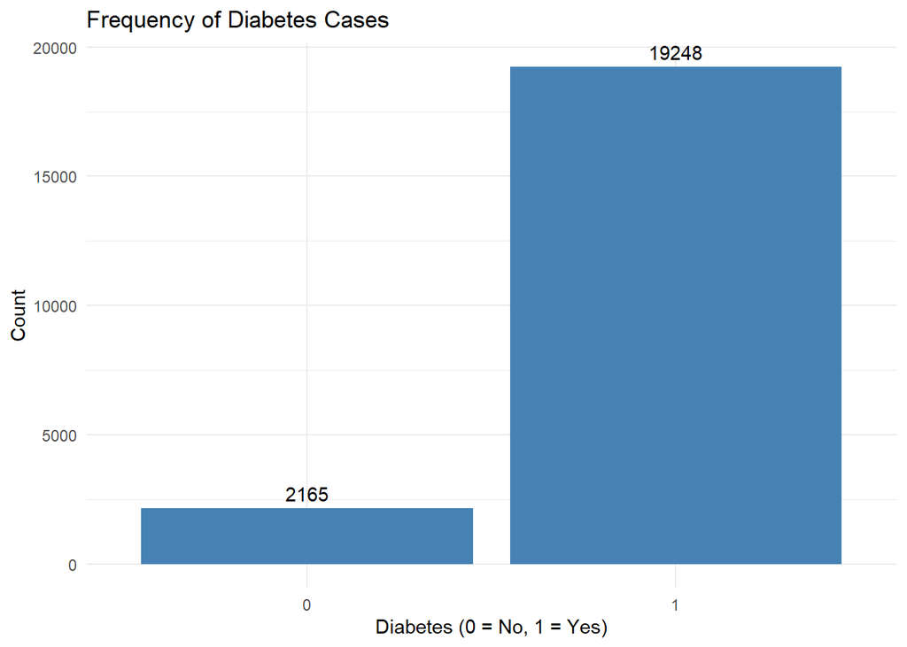

```r
ggplot(df_model, aes(x = factor(Diabetes))) +
  geom_bar(fill = "steelblue") +
  geom_text(stat = "count", aes(label = ..count..), vjust = -0.5) +
  labs(x = "Diabetes (0 = No, 1 = Yes)", y = "Count",
       title = "Frequency of Diabetes Cases") +
  theme_minimal()
```

Following feature selection, the reduced dataset with the top 10 variables includes 19248 individuals with diabetes and 2165 without. Therefore, we need to balance the dataset by undersampling the majority class.

1.11 Dataset Balancing Undersample Majority Class

```r
# 1. Check initial class distribution
table(df_model$Diabetes)
```

```
##
##     0     1
##  2165 19248
```

```r
# 2. Separate classes
yes_diabetes <- df_model %>% filter(Diabetes == 1)  # Majority
no_diabetes  <- df_model %>% filter(Diabetes == 0)  # Minority

# 3. Downsample majority class to match minority
set.seed(42)
yes_diabetes_downsampled <- yes_diabetes %>%
  slice_sample(n = nrow(no_diabetes), replace = FALSE)

# 4. Combine and shuffle
balanced_df_model <- bind_rows(no_diabetes, yes_diabetes_downsampled) %>%
  slice_sample(prop = 1)

# 5. Check new distribution
table(balanced_df_model$Diabetes)
```

```
##
##    0    1
## 2165 2165
```

```r
summary(balanced_df_model)
```

```
##       AGE           BMICALC          WEIGHT         HOURSWRK
##  Min.   :18.00   Min.   :15.40   Min.   :100.0   Min.   : 0.00
##  1st Qu.:47.00   1st Qu.:25.10   1st Qu.:155.2   1st Qu.: 0.00
##  Median :61.00   Median :28.70   Median :182.0   Median : 0.00
##  Mean   :58.53   Mean   :29.36   Mean   :186.8   Mean   :19.19
##  3rd Qu.:72.00   3rd Qu.:33.20   3rd Qu.:215.0   3rd Qu.:40.00
##  Max.   :85.00   Max.   :49.40   Max.   :299.0   Max.   :95.00
##    ALCDAYSYR           EDUC         VIG10DMIN         POVERTY
##  Min.   :  0.00   Min.   :103.0   Min.   :  0.00   Min.   :11.00
##  1st Qu.:  0.00   1st Qu.:201.0   1st Qu.:  0.00   1st Qu.:24.00
##  Median : 12.00   Median :301.0   Median :  0.00   Median :33.00
##  Mean   : 52.23   Mean   :303.9   Mean   : 16.27   Mean   :30.19
##  3rd Qu.: 52.00   3rd Qu.:400.0   3rd Qu.: 20.00   3rd Qu.:37.00
##  Max.   :365.00   Max.   :505.0   Max.   :600.00   Max.   :37.00
##    MOD10DMIN         ALCANYNO          Diabetes
##  Min.   :  0.00   Min.   :  0.000   Min.   :0.0
##  1st Qu.:  0.00   1st Qu.:  0.000   1st Qu.:0.0
##  Median : 30.00   Median :  1.000   Median :0.5
##  Mean   : 38.49   Mean   :  3.103   Mean   :0.5
##  3rd Qu.: 60.00   3rd Qu.:  3.000   3rd Qu.:1.0
##  Max.   :660.00   Max.   :365.000   Max.   :1.0
```

Result: Imbalanced dataset: 0 –> 2165, 1 –> 19248 Balanced dataset: 0 –> 2165, 1 –> 2165

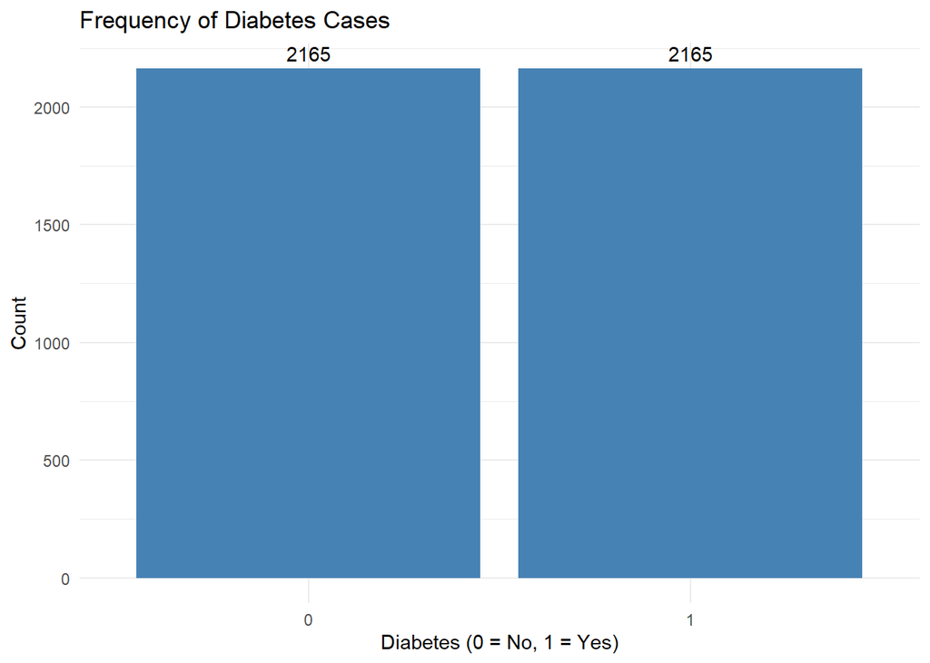

```r
ggplot(balanced_df_model, aes(x = factor(Diabetes))) +
  geom_bar(fill = "steelblue") +
  geom_text(stat = "count", aes(label = ..count..), vjust = -0.5) +
  labs(x = "Diabetes (0 = No, 1 = Yes)", y = "Count",
       title = "Frequency of Diabetes Cases") +
  theme_minimal()
```

Result: To correct class imbalance, the majority class was downsampled, resulting in an equal number of diabetic and non-diabetic cases 2165 each, as shown in the figure. This balanced dataset reduces model bias and improves the reliability of SVM classification.

Now, we build SVM models using the balanced dataset.

# 2.Linear SVM

# 2.1 Linear SVM

```r
# 1. Prepare balanced data
set.seed(123)
balanced_df_model_linear <- balanced_df_model %>%
  mutate(DiabetesTarget = as.factor(Diabetes))

# 2. Split into training and test sets
train_index <- createDataPartition(balanced_df_model_linear$DiabetesTarget, p = 0.7, list = FALSE)
train_df <- balanced_df_model_linear[train_index, ]
test_df  <- balanced_df_model_linear[-train_index, ]

# 3. Manually scale predictors
train_features <- train_df %>% select(-Diabetes, -DiabetesTarget)
test_features  <- test_df %>% select(-Diabetes, -DiabetesTarget)

scaled_train <- scale(train_features)
scaled_test  <- scale(test_features,
                      center = attr(scaled_train, "scaled:center"),
                      scale  = attr(scaled_train, "scaled:scale"))

# 4. Combine scaled features with target
train_data <- data.frame(scaled_train, DiabetesTarget = train_df$DiabetesTarget)
test_data  <- data.frame(scaled_test,  DiabetesTarget = test_df$DiabetesTarget)

# 5. Train Linear SVM (scale = FALSE to avoid double scaling)
svm_model_linear <- svm(
  DiabetesTarget ~ .,
  data = train_data,
  kernel = "linear",
  cost = 1,
  scale = FALSE
)

# 6. Predict on test data
predictions <- predict(svm_model_linear, newdata = test_data)

# 7. Confusion Matrix
conf_matrix <- confusionMatrix(predictions, test_data$DiabetesTarget)
print(conf_matrix)
```

```
## Confusion Matrix and Statistics
##
##           Reference
## Prediction   0   1
##          0 509 214
##          1 140 435
##
##                Accuracy : 0.7273
##                  95% CI : (0.7022, 0.7513)
##     No Information Rate : 0.5
##     P-Value [Acc > NIR] : < 2.2e-16
##
##                   Kappa : 0.4545
##
##  Mcnemar's Test P-Value : 0.0001045
##
##             Sensitivity : 0.7843
##             Specificity : 0.6703
##          Pos Pred Value : 0.7040
##          Neg Pred Value : 0.7565
##              Prevalence : 0.5000
##          Detection Rate : 0.3921
##    Detection Prevalence : 0.5570
##       Balanced Accuracy : 0.7273
##
##        'Positive' Class : 0
##
```

```r
# 8. Manual performance metrics
TP <- sum(predictions == "1" & test_data$DiabetesTarget == "1")
TN <- sum(predictions == "0" & test_data$DiabetesTarget == "0")
FP <- sum(predictions == "1" & test_data$DiabetesTarget == "0")
FN <- sum(predictions == "0" & test_data$DiabetesTarget == "1")

accuracy  <- mean(predictions == test_data$DiabetesTarget)
precision <- ifelse((TP + FP) == 0, 0, TP / (TP + FP))
recall    <- ifelse((TP + FN) == 0, 0, TP / (TP + FN))
f1_score  <- ifelse((precision + recall) == 0, 0,
                    2 * precision * recall / (precision + recall))

cat("\n Linear SVM Results :\n")
```

```
##
##  Linear SVM Results :
```

```r
cat("Accuracy :", round(accuracy, 4), "\n")
```

```
## Accuracy : 0.7273
```

```r
cat("Precision:", round(precision, 4), "\n")
```

```
## Precision: 0.7565
```

```r
cat("Recall   :", round(recall, 4), "\n")
```

```
## Recall   : 0.6703
```

```r
cat("F1-Score :", round(f1_score, 4), "\n")
```

```
## F1-Score : 0.7108
```

```r
# 9. Classification report
results_tbl <- tibble(
  truth = factor(test_data$DiabetesTarget, levels = c("0", "1")),
  prediction = factor(predictions, levels = c("0", "1"))
)

# Compute metrics for class "0"
class_0 <- results_tbl %>%
  summarise(
    precision = precision_vec(truth, prediction, estimator = "binary", event_level = "second"),
    recall = recall_vec(truth, prediction, estimator = "binary", event_level = "second"),
    f1 = f_meas_vec(truth, prediction, estimator = "binary", event_level = "second"),
    support = sum(truth == "0")
  )

# Reverse levels to compute metrics for class "1"
class_1 <- results_tbl %>%
  mutate(truth = fct_rev(truth), prediction = fct_rev(prediction)) %>%
  summarise(
    precision = precision_vec(truth, prediction, estimator = "binary", event_level = "second"),
    recall = recall_vec(truth, prediction, estimator = "binary", event_level = "second"),
    f1 = f_meas_vec(truth, prediction, estimator = "binary", event_level = "second"),
    support = sum(truth == "1")
  )

# Combine both
class_report <- bind_rows(
  tibble(class = "No Diabetes", precision = class_0$precision, recall = class_0$recall, f1 = class_0$f1, support = class_0$support),
  tibble(class = "Yes Diabetes", precision = class_1$precision, recall = class_1$recall, f1 = class_1$f1, support = class_1$support)
)

# 10. Classification report
cat("\n Classification Report:\n")
```

```
##
##  Classification Report:
```

```r
for (i in 1:nrow(class_report)) {
  cat(sprintf(" %-12s | Precision: %.2f | Recall: %.2f | F1-Score: %.2f | Support: %d\n",
              class_report$class[i],
              class_report$precision[i],
              class_report$recall[i],
              class_report$f1[i],
              class_report$support[i]))
}
```

```
##  No Diabetes  | Precision: 0.76 | Recall: 0.67 | F1-Score: 0.71 | Support: 649
##  Yes Diabetes | Precision: 0.70 | Recall: 0.78 | F1-Score: 0.74 | Support: 649
```

```r
# 11. Averages
macro_avg <- class_report %>%
  summarise(across(precision:f1, mean, na.rm = TRUE))
weighted_avg <- class_report %>%
  summarise(across(precision:f1, ~weighted.mean(.x, class_report$support, na.rm = TRUE)))

cat(sprintf("\n Accuracy     : %.4f\n", accuracy))
```

```
##
##  Accuracy     : 0.7273
```

```r
cat(sprintf(" Macro Avg    : Precision %.2f | Recall %.2f | F1 %.2f\n",
            macro_avg$precision, macro_avg$recall, macro_avg$f1))
```

```
##  Macro Avg    : Precision 0.73 | Recall 0.73 | F1 0.73
```

```r
cat(sprintf(" Weighted Avg : Precision %.2f | Recall %.2f | F1 %.2f\n",
            weighted_avg$precision, weighted_avg$recall, weighted_avg$f1))
```

```
##  Weighted Avg : Precision 0.73 | Recall 0.73 | F1 0.73
```

# 2.1.1 Training and Test Errors of Linear SVM Model

```r
# Training predictions
training_predictions_linear <- predict(svm_model_linear, newdata = train_data)
training_accuracy_linear <- mean(training_predictions_linear == train_data$DiabetesTarget)
training_error_linear <- 1 - training_accuracy_linear

# Test predictions
test_accuracy_linear <- mean(predictions == test_data$DiabetesTarget)
test_error_linear <- 1 - test_accuracy_linear

# Results
cat("\n Linear SVM Training and Test Error Rates:\n")
```

```
##
##  Linear SVM Training and Test Error Rates:
```

```r
cat(sprintf(" Training Accuracy : %.4f\n", training_accuracy_linear))
```

```
##  Training Accuracy : 0.7210
```

```r
cat(sprintf(" Training Error     : %.4f\n", training_error_linear))
```

```
##  Training Error     : 0.2790
```

```r
cat(sprintf(" Test Accuracy      : %.4f\n", test_accuracy_linear))
```

```
##  Test Accuracy      : 0.7273
```

```r
cat(sprintf(" Test Error         : %.4f\n", test_error_linear))
```

```
##  Test Error         : 0.2727
```

# 2.2 Tuned Linear SVM

```r
# 1. Tune SVM
cost_values <- c(0.1, 1, 10, 100)

set.seed(123)
tuned_svm_model <- tune(
  svm,
  DiabetesTarget ~ .,
  data = train_data,
  kernel = "linear",
  ranges = list(cost = cost_values),
  scale = FALSE,
  tunecontrol = tune.control(cross = 10)
)

# 2. Best model
best_svm_tuned <- tuned_svm_model$best.model
cat("Best Cost Selected:", tuned_svm_model$best.parameters$cost, "\n")
```

```
## Best Cost Selected: 1
```

```r
# 3. Predict on test data
predictions <- predict(best_svm_tuned, newdata = test_data)

# 4. Confusion Matrix
conf_matrix <- confusionMatrix(predictions, test_data$DiabetesTarget)
print(conf_matrix)
```

```
## Confusion Matrix and Statistics
##
##           Reference
## Prediction   0   1
##          0 509 214
##          1 140 435
##
##                Accuracy : 0.7273
##                  95% CI : (0.7022, 0.7513)
##     No Information Rate : 0.5
##     P-Value [Acc > NIR] : < 2.2e-16
##
##                   Kappa : 0.4545
##
##  Mcnemar's Test P-Value : 0.0001045
##
##             Sensitivity : 0.7843
##             Specificity : 0.6703
##          Pos Pred Value : 0.7040
##          Neg Pred Value : 0.7565
##              Prevalence : 0.5000
##          Detection Rate : 0.3921
##    Detection Prevalence : 0.5570
##       Balanced Accuracy : 0.7273
##
##        'Positive' Class : 0
##
```

```r
# 5. Manual performance metrics
TP <- sum(predictions == "1" & test_data$DiabetesTarget == "1")
TN <- sum(predictions == "0" & test_data$DiabetesTarget == "0")
FP <- sum(predictions == "1" & test_data$DiabetesTarget == "0")
FN <- sum(predictions == "0" & test_data$DiabetesTarget == "1")

accuracy_tuned_linear  <- mean(predictions == test_data$DiabetesTarget)
precision_tuned_linear <- ifelse((TP + FP) == 0, 0, TP / (TP + FP))
recall_tuned_linear    <- ifelse((TP + FN) == 0, 0, TP / (TP + FN))
f1_score_tuned_linear  <- ifelse((precision_tuned_linear + recall_tuned_linear) == 0, 0,
                    2 * precision_tuned_linear * recall_tuned_linear / (precision_tuned_linear + recall_tuned_linear))

cat("\n Tuned Linear SVM Results :\n")
```

```
##
##  Tuned Linear SVM Results :
```

```r
cat("Accuracy :", round(accuracy_tuned_linear, 4), "\n")
```

```
## Accuracy : 0.7273
```

```r
cat("Precision:", round(precision_tuned_linear, 4), "\n")
```

```
## Precision: 0.7565
```

```r
cat("Recall   :", round(recall_tuned_linear, 4), "\n")
```

```
## Recall   : 0.6703
```

```r
cat("F1-Score :", round(f1_score_tuned_linear, 4), "\n")
```

```
## F1-Score : 0.7108
```

```r
# 6. Classification report
results_tbl <- tibble(
  truth = factor(test_data$DiabetesTarget, levels = c("0", "1")),
  prediction = factor(predictions, levels = c("0", "1"))
)

# Metrics for class 0
class_0 <- results_tbl %>%
  summarise(
    precision_tuned_linear = precision_vec(truth, prediction, estimator = "binary", event_level = "second"),
    recall_tuned_linear = recall_vec(truth, prediction, estimator = "binary", event_level = "second"),
    f1 = f_meas_vec(truth, prediction, estimator = "binary", event_level = "second"),
    support = sum(truth == "0")
  )

# Metrics for class 1
class_1 <- results_tbl %>%
  mutate(truth = fct_rev(truth), prediction = fct_rev(prediction)) %>%
  summarise(
    precision_tuned_linear = precision_vec(truth, prediction, estimator = "binary", event_level = "second"),
    recall_tuned_linear = recall_vec(truth, prediction, estimator = "binary", event_level = "second"),
    f1 = f_meas_vec(truth, prediction, estimator = "binary", event_level = "second"),
    support = sum(truth == "1")
  )

# Combine report
class_report <- bind_rows(
  tibble(class = "No Diabetes", precision_tuned_linear = class_0$precision_tuned_linear, recall_tuned_linear = class_0$recall_tuned_linear, f1 = class_0$f1, support = class_0$support),
  tibble(class = "Yes Diabetes", precision_tuned_linear = class_1$precision_tuned_linear, recall_tuned_linear = class_1$recall_tuned_linear, f1 = class_1$f1, support = class_1$support)
)

# 7. Classification report
cat("\n Classification Report:\n")
```

```
##
##  Classification Report:
```

```r
for (i in 1:nrow(class_report)) {
  cat(sprintf(" %-12s | Precision: %.2f | Recall: %.2f | F1-Score: %.2f | Support: %d\n",
              class_report$class[i],
              class_report$precision_tuned_linear[i],
              class_report$recall_tuned_linear[i],
              class_report$f1[i],
              class_report$support[i]))
}
```

```
##  No Diabetes  | Precision: 0.76 | Recall: 0.67 | F1-Score: 0.71 | Support: 649
##  Yes Diabetes | Precision: 0.70 | Recall: 0.78 | F1-Score: 0.74 | Support: 649
```

```r
# 8. Averages
macro_avg <- class_report %>%
  summarise(across(precision_tuned_linear:f1, mean, na.rm = TRUE))

weighted_avg <- class_report %>%
  summarise(across(precision_tuned_linear:f1, ~weighted.mean(.x, class_report$support, na.rm = TRUE)))

cat(sprintf("\n Accuracy     : %.4f\n", accuracy_tuned_linear))
```

```
##
##  Accuracy     : 0.7273
```

```r
cat(sprintf(" Macro Avg    : Precision %.2f | Recall %.2f | F1 %.2f\n",
            macro_avg$precision_tuned_linear, macro_avg$recall_tuned_linear, macro_avg$f1))
```

```
##  Macro Avg    : Precision 0.73 | Recall 0.73 | F1 0.73
```

```r
cat(sprintf(" Weighted Avg : Precision %.2f | Recall %.2f | F1 %.2f\n",
            weighted_avg$precision_tuned_linear, weighted_avg$recall_tuned_linear, weighted_avg$f1))
```

```
##  Weighted Avg : Precision 0.73 | Recall 0.73 | F1 0.73
```

# 2.2.1 Training and Test Errors of Tuned Linear SVM Model

```r
# Training predictions
train_predictions_tuned_linear <- predict(best_svm_tuned, newdata = train_data)
training_accuracy_tuned_linear <- mean(train_predictions_tuned_linear == train_data$DiabetesTarget)
test_accuracy_tuned_linear    <- mean(predictions == test_data$DiabetesTarget)

# Test predictions
training_error_tuned_linear <- 1 - training_accuracy_tuned_linear
test_error_tuned_linear     <- 1 - test_accuracy_tuned_linear

# Results
cat("\n Tuned Linear SVM Accuracy and Error Rates:\n")
```

```
##
##  Tuned Linear SVM Accuracy and Error Rates:
```

```r
cat(sprintf(" Training Accuracy : %.4f\n", training_accuracy_tuned_linear))
```

```
##  Training Accuracy : 0.7210
```

```r
cat(sprintf(" Training Error    : %.4f\n", training_error_tuned_linear))
```

```
##  Training Error    : 0.2790
```

```r
cat(sprintf(" Test Accuracy     : %.4f\n", test_accuracy_tuned_linear))
```

```
##  Test Accuracy     : 0.7273
```

```r
cat(sprintf(" Test Error        : %.4f\n", test_error_tuned_linear))
```

```
##  Test Error        : 0.2727
```

# 2.2.2 Important Variables of Tuned Linear SVM

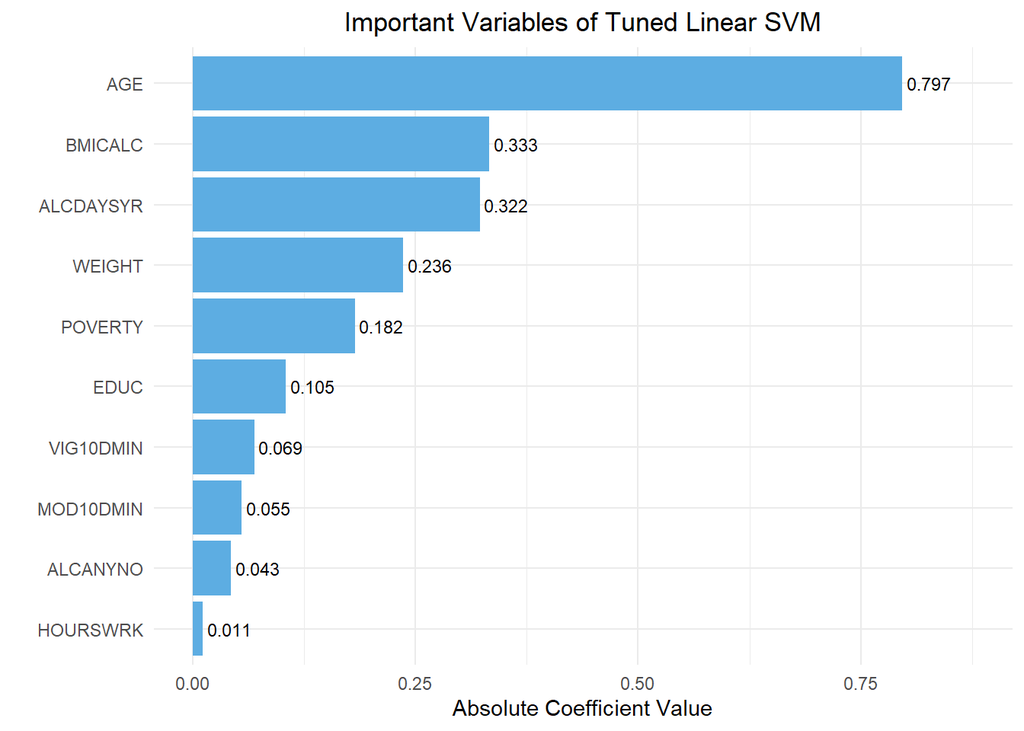

```r
# 1. Select features and define SVM data
svm_data <- train_data %>%
  select(AGE, BMICALC, WEIGHT, HOURSWRK, ALCDAYSYR, EDUC, VIG10DMIN, POVERTY, MOD10DMIN, ALCANYNO, DiabetesTarget) %>%
  mutate(DiabetesTarget = factor(DiabetesTarget))

# 2. Hyperparameter tuning (cost)
set.seed(123)
cost_values <- c(0.01, 0.1, 1, 10, 100)
tuned_linear_model <- tune(
  svm,
  DiabetesTarget ~ .,
  data = svm_data,
  kernel = "linear",
  ranges = list(cost = cost_values),
  scale = TRUE
)

# 3. Extract best model and compute coefficients
best_svm_model <- tuned_linear_model$best.model
w <- t(best_svm_model$coefs) %*% best_svm_model$SV

# 4. Create feature importance table
feature_names <- c("AGE", "BMICALC", "WEIGHT", "HOURSWRK", "ALCDAYSYR",
                   "EDUC", "VIG10DMIN", "POVERTY", "MOD10DMIN", "ALCANYNO")

importance_df <- data.frame(
  Variable = feature_names,
  Coefficient = as.vector(w)
) %>%
  mutate(AbsCoefficient = abs(Coefficient)) %>%
  arrange(desc(AbsCoefficient))

# 5. Plot variable importance
ggplot(importance_df, aes(x = reorder(Variable, AbsCoefficient), y = AbsCoefficient)) +
  geom_bar(stat = "identity", fill = "#5DADE2") +
  geom_text(aes(label = round(AbsCoefficient, 3)),
            hjust = -0.1, size = 3, color = "black") +
  coord_flip() +
  labs(
    title = "Important Variables of Tuned Linear SVM",
    x = "",
    y = "Absolute Coefficient Value"
  ) +
  theme_minimal() +
  theme(plot.title = element_text(hjust = 0.5)) +
  ylim(0, max(importance_df$AbsCoefficient) * 1.1)
```

Result: The tuned Linear SVM model identified age as the most influential predictor of diabetes, followed by body mass index and alcohol consumption frequency. Moderate effects were seen from weight and poverty level, while education, physical activity, and work hours had minimal impact. These findings highlight the key role of demographic and lifestyle factors, especially age and body mass index in diabetes prediction.

# 2.2.3 Decision Boundary of Tuned Linear SMV Model with Top 2 Variables

A decision boundary shows how the model makes decisions between classes.

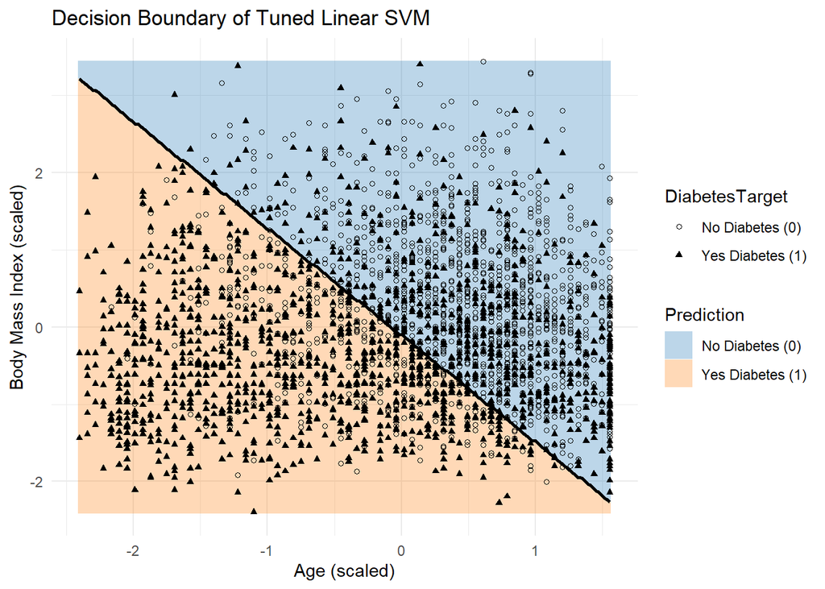

```r
# 1. Train data: AGE and BMICALC
scaled_Age <- scale(train_data$AGE)
scaled_BMI <- scale(train_data$BMICALC)

train_plot_df <- train_data %>%
  mutate(
    Age = as.numeric(scaled_Age),
    BMI = as.numeric(scaled_BMI),
    DiabetesTarget = factor(DiabetesTarget)
  ) %>%
  select(Age, BMI, DiabetesTarget)

# 2. Tuned SVM model
set.seed(123)
svm_tuned_best2variables <- tune(
  svm,
  DiabetesTarget ~ Age + BMI,
  data = train_plot_df,
  kernel = "linear",
  ranges = list(cost = c(0.1, 1, 10, 100)),
  scale = FALSE
)$best.model

# 3. Grid to visualize the decision surface
x_range <- seq(min(train_plot_df$Age), max(train_plot_df$Age), length.out = 200)
y_range <- seq(min(train_plot_df$BMI), max(train_plot_df$BMI), length.out = 200)
grid <- expand.grid(Age = x_range, BMI = y_range)
grid$pred <- predict(svm_tuned_best2variables, newdata = grid)

# 4. Decision boundary plot
ggplot() +
  geom_tile(data = grid, aes(x = Age, y = BMI, fill = pred), alpha = 0.3) +
  scale_fill_manual(
    values = c("0" = "#1f77b4", "1" = "#ff7f0e"),
    name = "Prediction",
    labels = c("No Diabetes (0)", "Yes Diabetes (1)")
  ) +
  geom_point(data = train_plot_df, aes(x = Age, y = BMI, shape = DiabetesTarget), color = "black", size = 1.3) +
  scale_shape_manual(values = c(1, 17), labels = c("No Diabetes (0)", "Yes Diabetes (1)")) +
  geom_contour(
    data = grid,
    aes(x = Age, y = BMI, z = as.numeric(pred)),
    breaks = 1.5,
    color = "black",
    size = 1
  ) +
  labs(
    title = "Decision Boundary of Tuned Linear SVM",
    x = "Age (scaled)",
    y = "Body Mass Index (scaled)"
  ) +
  theme_minimal() +
  theme(legend.position = "right")
```

```r
# 5. Scale the test data
test_plot_df <- test_data %>%
  mutate(
    Age = as.numeric(scale(AGE,
      center = attr(scaled_Age, "scaled:center"),
      scale  = attr(scaled_Age, "scaled:scale")
    )),
    BMI = as.numeric(scale(BMICALC,
      center = attr(scaled_BMI, "scaled:center"),
      scale  = attr(scaled_BMI, "scaled:scale")
    )),
    DiabetesTarget = factor(DiabetesTarget)
  ) %>%
  select(Age, BMI, DiabetesTarget)

# 6. Predict and Accuracy
test_pred_linear <- predict(svm_tuned_best2variables, newdata = test_plot_df)
test_accuracy_linear <- mean(test_pred_linear == test_plot_df$DiabetesTarget)

# 7. Result
cat(sprintf("Test Accuracy of Linear SVM: %.4f\n", test_accuracy_linear))
```

```
## Test Accuracy of Linear SVM: 0.7180
```

This decision boundary uses the top 2 variables to visually demonstrate how the Linear SVM model classifies the data. The model correctly predicted the diabetes status 71.8% of the time.

# 3. Radial SVM

# 3.1 Radial SVM

```r
# 1. Train Radial SVM
radial_svm_model <- svm(
  DiabetesTarget ~ .,
  data = train_data,
  kernel = "radial",
  cost = 1,
  scale = FALSE
)

# 2. Predictions
train_pred_radial <- predict(radial_svm_model, newdata = train_data)
test_pred_radial  <- predict(radial_svm_model, newdata = test_data)

# 3. Confusion Matrix
cat("\n Confusion Matrix (Test Data):\n")
```

```
##
##  Confusion Matrix (Test Data):
```

```r
print(confusionMatrix(test_pred_radial, test_data$DiabetesTarget))
```

```
## Confusion Matrix and Statistics
##
##           Reference
## Prediction   0   1
##          0 527 226
##          1 122 423
##
##                Accuracy : 0.7319
##                  95% CI : (0.7069, 0.7558)
##     No Information Rate : 0.5
##     P-Value [Acc > NIR] : < 2.2e-16
##
##                   Kappa : 0.4638
##
##  Mcnemar's Test P-Value : 3.363e-08
##
##             Sensitivity : 0.8120
##             Specificity : 0.6518
##          Pos Pred Value : 0.6999
##          Neg Pred Value : 0.7761
##              Prevalence : 0.5000
##          Detection Rate : 0.4060
##    Detection Prevalence : 0.5801
##       Balanced Accuracy : 0.7319
##
##        'Positive' Class : 0
##
```

```r
# 4. Manual Performance Metrics
TP <- sum(test_pred_radial == "1" & test_data$DiabetesTarget == "1")
TN <- sum(test_pred_radial == "0" & test_data$DiabetesTarget == "0")
FP <- sum(test_pred_radial == "1" & test_data$DiabetesTarget == "0")
FN <- sum(test_pred_radial == "0" & test_data$DiabetesTarget == "1")

accuracy <- mean(test_pred_radial == test_data$DiabetesTarget)
precision <- ifelse((TP + FP) == 0, 0, TP / (TP + FP))
recall    <- ifelse((TP + FN) == 0, 0, TP / (TP + FN))
f1_score  <- ifelse((precision + recall) == 0, 0,
                    2 * precision * recall / (precision + recall))

cat("\n Radial SVM Results (Balanced & Scaled):\n")
```

```
##
##  Radial SVM Results (Balanced & Scaled):
```

```r
cat("Accuracy :", round(accuracy, 4), "\n")
```

```
## Accuracy : 0.7319
```

```r
cat("Precision:", round(precision, 4), "\n")
```

```
## Precision: 0.7761
```

```r
cat("Recall   :", round(recall, 4), "\n")
```

```
## Recall   : 0.6518
```

```r
cat("F1-Score :", round(f1_score, 4), "\n")
```

```
## F1-Score : 0.7085
```

```r
# 5. Classification Report
results_tbl <- tibble(
  truth = factor(test_data$DiabetesTarget, levels = c("0", "1")),
  prediction = factor(test_pred_radial, levels = c("0", "1"))
)

# Metrics for class 0
class_0 <- results_tbl %>%
  summarise(
    precision = precision_vec(truth, prediction, estimator = "binary", event_level = "second"),
    recall    = recall_vec(truth, prediction, estimator = "binary", event_level = "second"),
    f1        = f_meas_vec(truth, prediction, estimator = "binary", event_level = "second"),
    support   = sum(truth == "0")
  )

# Metrics for class 1
class_1 <- results_tbl %>%
  mutate(truth = fct_rev(truth), prediction = fct_rev(prediction)) %>%
  summarise(
    precision = precision_vec(truth, prediction, estimator = "binary", event_level = "second"),
    recall    = recall_vec(truth, prediction, estimator = "binary", event_level = "second"),
    f1        = f_meas_vec(truth, prediction, estimator = "binary", event_level = "second"),
    support   = sum(truth == "1")
  )

# Combine report
class_report <- bind_rows(
  tibble(class = "No Diabetes", precision = class_0$precision, recall = class_0$recall, f1 = class_0$f1, support = class_0$support),
  tibble(class = "Yes Diabetes", precision = class_1$precision, recall = class_1$recall, f1 = class_1$f1, support = class_1$support)
)

# 6. Classification report
cat("\n Classification Report:\n")
```

```
##
##  Classification Report:
```

```r
for (i in 1:nrow(class_report)) {
  cat(sprintf(" %-12s | Precision: %.2f | Recall: %.2f | F1-Score: %.2f | Support: %d\n",
              class_report$class[i],
              class_report$precision[i],
              class_report$recall[i],
              class_report$f1[i],
              class_report$support[i]))
}
```

```
##  No Diabetes  | Precision: 0.78 | Recall: 0.65 | F1-Score: 0.71 | Support: 649
##  Yes Diabetes | Precision: 0.70 | Recall: 0.81 | F1-Score: 0.75 | Support: 649
```

```r
# 7. Averages
macro_avg <- class_report %>%
  summarise(across(precision:f1, mean, na.rm = TRUE))

weighted_avg <- class_report %>%
  summarise(across(precision:f1, ~weighted.mean(.x, class_report$support, na.rm = TRUE)))

cat(sprintf("\n Accuracy     : %.4f\n", accuracy))
```

```
##
##  Accuracy     : 0.7319
```

```r
cat(sprintf(" Macro Avg    : Precision %.2f | Recall %.2f | F1 %.2f\n",
            macro_avg$precision, macro_avg$recall, macro_avg$f1))
```

```
##  Macro Avg    : Precision 0.74 | Recall 0.73 | F1 0.73
```

```r
cat(sprintf(" Weighted Avg : Precision %.2f | Recall %.2f | F1 %.2f\n",
            weighted_avg$precision, weighted_avg$recall, weighted_avg$f1))
```

```
##  Weighted Avg : Precision 0.74 | Recall 0.73 | F1 0.73
```

# 3.1.1 Training and Test Errors of Radial SVM Model

```r
# Training predictions
train_acc_radial <- mean(train_pred_radial == train_data$DiabetesTarget)
test_acc_radial  <- mean(test_pred_radial == test_data$DiabetesTarget)

# Test predictions
train_err_radial <- 1 - train_acc_radial
test_err_radial  <- 1 - test_acc_radial

# Results
cat("\n Radial SVM Accuracy and Error Rates:\n")
```

```
##
##  Radial SVM Accuracy and Error Rates:
```

```r
cat(sprintf(" Training Accuracy : %.4f\n", train_acc_radial))
```

```
##  Training Accuracy : 0.7460
```

```r
cat(sprintf(" Training Error    : %.4f\n", train_err_radial))
```

```
##  Training Error    : 0.2540
```

```r
cat(sprintf(" Test Accuracy     : %.4f\n", test_acc_radial))
```

```
##  Test Accuracy     : 0.7319
```

```r
cat(sprintf(" Test Error        : %.4f\n", test_err_radial))
```

```
##  Test Error        : 0.2681
```

Result: Training accuracy: 74.6% Test accuracy: 73.1% Training Error: 25.4% Test Error: 26.8% The radial SVM shows stable and consistent performance across training and test sets, indicating a well generalized model that does not overfit or underfit the data.

Now, using the tuned radial SVM, the model’s performance improves with higher accuracy and more balanced precision and recall. Most importantly, it classifies the true classes more reliably and accurately.

# 3.2 Tuned Radial SVM

```r
# 1. Tuning grid
cost_values <- c(0.1, 1, 10, 100)
gamma_values <- c(0.001, 0.01, 0.1, 1.0)

# 2. Tune Radial SVM
set.seed(123)
tuned_radial <- tune(
  svm,
  DiabetesTarget ~ .,
  data = train_data,
  kernel = "radial",
  ranges = list(cost = cost_values, gamma = gamma_values),
  scale = FALSE,
  tunecontrol = tune.control(cross = 10)
)

# 3. Best model
tuned_radial_svm_model <- tuned_radial$best.model
cat("\n Tuned Radial SVM Best Parameters:\n")
```

```
##
##  Tuned Radial SVM Best Parameters:
```

```r
print(tuned_radial$best.parameters)
```

```
##   cost gamma
## 3   10 0.001
```

```r
# 4. Predictions
train_pred_radial <- predict(tuned_radial_svm_model, newdata = train_data)
test_pred_radial  <- predict(tuned_radial_svm_model, newdata = test_data)

# 5. Confusion Matrix
cat("\n Confusion Matrix (Test Data):\n")
```

```
##
##  Confusion Matrix (Test Data):
```

```r
print(confusionMatrix(test_pred_radial, test_data$DiabetesTarget))
```

```
## Confusion Matrix and Statistics
##
##           Reference
## Prediction   0   1
##          0 511 209
##          1 138 440
##
##                Accuracy : 0.7327
##                  95% CI : (0.7077, 0.7566)
##     No Information Rate : 0.5
##     P-Value [Acc > NIR] : < 2.2e-16
##
##                   Kappa : 0.4653
##
##  Mcnemar's Test P-Value : 0.0001714
##
##             Sensitivity : 0.7874
##             Specificity : 0.6780
##          Pos Pred Value : 0.7097
##          Neg Pred Value : 0.7612
##              Prevalence : 0.5000
##          Detection Rate : 0.3937
##    Detection Prevalence : 0.5547
##       Balanced Accuracy : 0.7327
##
##        'Positive' Class : 0
##
```

```r
# 6. Manual performance metrics
TP <- sum(test_pred_radial == "1" & test_data$DiabetesTarget == "1")
TN <- sum(test_pred_radial == "0" & test_data$DiabetesTarget == "0")
FP <- sum(test_pred_radial == "1" & test_data$DiabetesTarget == "0")
FN <- sum(test_pred_radial == "0" & test_data$DiabetesTarget == "1")

accuracy  <- mean(test_pred_radial == test_data$DiabetesTarget)
precision <- ifelse((TP + FP) == 0, 0, TP / (TP + FP))
recall    <- ifelse((TP + FN) == 0, 0, TP / (TP + FN))
f1_score  <- ifelse((precision + recall) == 0, 0,
                    2 * precision * recall / (precision + recall))

cat("\n Tuned Radial SVM Results (Balanced & Scaled):\n")
```

```
##
##  Tuned Radial SVM Results (Balanced & Scaled):
```

```r
cat("Accuracy :", round(accuracy, 4), "\n")
```

```
## Accuracy : 0.7327
```

```r
cat("Precision:", round(precision, 4), "\n")
```

```
## Precision: 0.7612
```

```r
cat("Recall   :", round(recall, 4), "\n")
```

```
## Recall   : 0.678
```

```r
cat("F1-Score :", round(f1_score, 4), "\n")
```

```
## F1-Score : 0.7172
```

```r
# 7. Classification report
results_tbl <- tibble(
  truth = factor(test_data$DiabetesTarget, levels = c("0", "1")),
  prediction = factor(test_pred_radial, levels = c("0", "1"))
)

# Metrics for class 0
class_0 <- results_tbl %>%
  summarise(
    precision = precision_vec(truth, prediction, estimator = "binary", event_level = "second"),
    recall    = recall_vec(truth, prediction, estimator = "binary", event_level = "second"),
    f1        = f_meas_vec(truth, prediction, estimator = "binary", event_level = "second"),
    support   = sum(truth == "0")
  )

# Metrics for class 1
class_1 <- results_tbl %>%
  mutate(truth = fct_rev(truth), prediction = fct_rev(prediction)) %>%
  summarise(
    precision = precision_vec(truth, prediction, estimator = "binary", event_level = "second"),
    recall    = recall_vec(truth, prediction, estimator = "binary", event_level = "second"),
    f1        = f_meas_vec(truth, prediction, estimator = "binary", event_level = "second"),
    support   = sum(truth == "1")
  )

# Combine report
class_report <- bind_rows(
  tibble(class = "No Diabetes", precision = class_0$precision, recall = class_0$recall, f1 = class_0$f1, support = class_0$support),
  tibble(class = "Yes Diabetes", precision = class_1$precision, recall = class_1$recall, f1 = class_1$f1, support = class_1$support)
)

# 8. Classification report
cat("\n Classification Report:\n")
```

```
##
##  Classification Report:
```

```r
for (i in 1:nrow(class_report)) {
  cat(sprintf(" %-12s | Precision: %.2f | Recall: %.2f | F1-Score: %.2f | Support: %d\n",
              class_report$class[i],
              class_report$precision[i],
              class_report$recall[i],
              class_report$f1[i],
              class_report$support[i]))
}
```

```
##  No Diabetes  | Precision: 0.76 | Recall: 0.68 | F1-Score: 0.72 | Support: 649
##  Yes Diabetes | Precision: 0.71 | Recall: 0.79 | F1-Score: 0.75 | Support: 649
```

```r
# 9. Averages
macro_avg <- class_report %>%
  summarise(across(precision:f1, mean, na.rm = TRUE))

weighted_avg <- class_report %>%
  summarise(across(precision:f1, ~weighted.mean(.x, class_report$support, na.rm = TRUE)))

cat(sprintf("\n Accuracy     : %.4f\n", accuracy))
```

```
##
##  Accuracy     : 0.7327
```

```r
cat(sprintf(" Macro Avg    : Precision %.2f | Recall %.2f | F1 %.2f\n",
            macro_avg$precision, macro_avg$recall, macro_avg$f1))
```

```
##  Macro Avg    : Precision 0.74 | Recall 0.73 | F1 0.73
```

```r
cat(sprintf(" Weighted Avg : Precision %.2f | Recall %.2f | F1 %.2f\n",
            weighted_avg$precision, weighted_avg$recall, weighted_avg$f1))
```

```
##  Weighted Avg : Precision 0.74 | Recall 0.73 | F1 0.73
```

# 3.2.1 Training and Test Errors of Tuned Radial SVM Model

```r
# Predictions
train_pred_tuned_radial <- predict(tuned_radial_svm_model, newdata = train_data)
test_pred_tuned_radial  <- predict(tuned_radial_svm_model, newdata = test_data)

# Training predictions
train_acc_tuned_radial <- mean(train_pred_tuned_radial == train_data$DiabetesTarget)
test_acc_tuned_radial  <- mean(test_pred_tuned_radial == test_data$DiabetesTarget)

# Test predictions
train_err_tuned_radial <- 1 - train_acc_tuned_radial
test_err_tuned_radial  <- 1 - test_acc_tuned_radial

# Results
cat("\n Tuned Radial SVM Accuracy and Error Rates:\n")
```

```
##
##  Tuned Radial SVM Accuracy and Error Rates:
```

```r
cat(sprintf(" Training Accuracy : %.4f\n", train_acc_tuned_radial))
```

```
##  Training Accuracy : 0.7216
```

```r
cat(sprintf(" Training Error    : %.4f\n", train_err_tuned_radial))
```

```
##  Training Error    : 0.2784
```

```r
cat(sprintf(" Test Accuracy     : %.4f\n", test_acc_tuned_radial))
```

```
##  Test Accuracy     : 0.7327
```

```r
cat(sprintf(" Test Error        : %.4f\n", test_err_tuned_radial))
```

```
##  Test Error        : 0.2673
```

Result: Training accuracy: 72.1% Test accuracy: 73.2% Training Error: 27.8% Test Error: 26.7% The tuned radial SVM shows strong generalization, with similar training 72.1% and test 73.2% accuracies. This indicates consistent performance without overfitting.

# 3.2.2 Decision Boundary of Tuned Radial SMV Model with Top 2 Variables

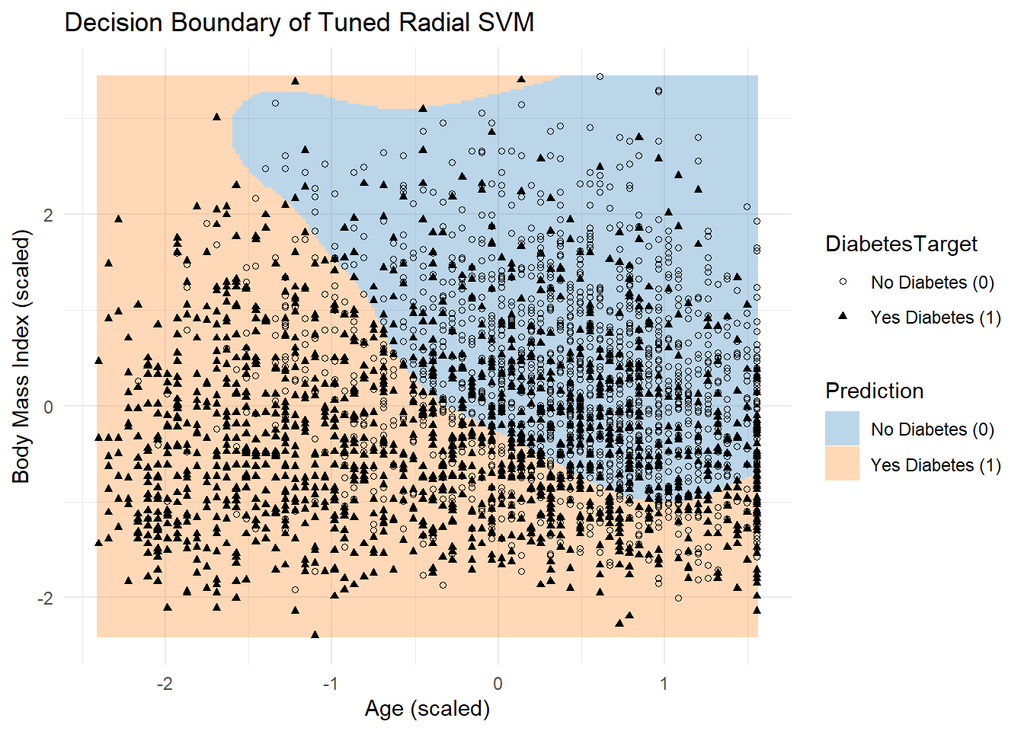

```r
# 1. Train data: AGE and BMICALC
plot_data <- train_data %>%
  select(Age = AGE, BMI = BMICALC, DiabetesTarget) %>%
  mutate(DiabetesTarget = factor(DiabetesTarget))

# 2. Scale
scaled_Age <- scale(plot_data$Age)
scaled_BMI <- scale(plot_data$BMI)

plot_data$Age <- as.numeric(scaled_Age)
plot_data$BMI <- as.numeric(scaled_BMI)

# 3. Tuned Radial SVM model
set.seed(123)
tuned_radial_best2variables <- tune(
  svm,
  DiabetesTarget ~ Age + BMI,
  data = plot_data,
  kernel = "radial",
  ranges = list(cost = c(0.1, 1, 10, 100), gamma = c(0.001, 0.01, 0.1, 1.0)),
  scale = FALSE
)$best.model

# 4. Grid to visualize the decision surface
x_range <- seq(min(plot_data$Age), max(plot_data$Age), length.out = 200)
y_range <- seq(min(plot_data$BMI), max(plot_data$BMI), length.out = 200)
grid <- expand.grid(Age = x_range, BMI = y_range)
grid$pred <- predict(tuned_radial_best2variables, newdata = grid)

# 5. Decision boundary plot
ggplot() +
  geom_tile(data = grid, aes(x = Age, y = BMI, fill = pred), alpha = 0.3) +
  scale_fill_manual(
    values = c("0" = "#1f77b4", "1" = "#ff7f0e"),
    name = "Prediction",
    labels = c("No Diabetes (0)", "Yes Diabetes (1)")
  ) +
  geom_point(data = plot_data, aes(x = Age, y = BMI, shape = DiabetesTarget), color = "black", size = 1.3) +
  scale_shape_manual(
    values = c(1, 17),
    labels = c("No Diabetes (0)", "Yes Diabetes (1)")
  ) +
  labs(
    title = "Decision Boundary of Tuned Radial SVM",
    x = "Age (scaled)",
    y = "Body Mass Index (scaled)"
  ) +
  theme_minimal()
```

```r
# 6. Scale the test data
test_plot_data <- test_data %>%
  select(Age = AGE, BMI = BMICALC, DiabetesTarget) %>%
  mutate(DiabetesTarget = factor(DiabetesTarget))

test_plot_data$Age <- scale(test_plot_data$Age,
                            center = attr(scaled_Age, "scaled:center"),
                            scale = attr(scaled_Age, "scaled:scale"))[,1]

test_plot_data$BMI <- scale(test_plot_data$BMI,
                            center = attr(scaled_BMI, "scaled:center"),
                            scale = attr(scaled_BMI, "scaled:scale"))[,1]

# 7. Predict on test set
test_pred <- predict(tuned_radial_best2variables, newdata = test_plot_data)

# 8. Accuracy
test_accuracy <- mean(test_pred == test_plot_data$DiabetesTarget)

# 9. Result
cat(sprintf("Test Accuracy of Radial SVM: %.4f\n", test_accuracy))
```

```
## Test Accuracy of Radial SVM: 0.7211
```

The use of the radial kernel likely improved performance by capturing nonlinear patterns in the data. The tuned radial SVM effectively learns complex, non-linear relationships between Age and BMI, making it more flexible than linear models. This decision boundary, based on the top two variables, visually demonstrates how the model classifies diabetes status. The model achieved a test accuracy of 72.1%.

# 4. Polynomial SVM

# 4.1 Polynomial SVM

```r
# 1. Polynomial SVM
poly_svm_model <- svm(
  DiabetesTarget ~ .,
  data = train_data,
  kernel = "polynomial",
  degree = 3,
  cost = 1,
  scale = FALSE
)

# 2. Predictions
train_pred_poly <- predict(poly_svm_model, newdata = train_data)
test_pred_poly  <- predict(poly_svm_model, newdata = test_data)

# 3. Confusion Matrix
cat("\n Confusion Matrix (Test Data):\n")
```

```
##
##  Confusion Matrix (Test Data):
```

```r
print(confusionMatrix(test_pred_poly, test_data$DiabetesTarget))
```

```
## Confusion Matrix and Statistics
##
##           Reference
## Prediction   0   1
##          0 554 263
##          1  95 386
##
##                Accuracy : 0.7242
##                  95% CI : (0.699, 0.7484)
##     No Information Rate : 0.5
##     P-Value [Acc > NIR] : < 2.2e-16
##
##                   Kappa : 0.4484
##
##  Mcnemar's Test P-Value : < 2.2e-16
##
##             Sensitivity : 0.8536
##             Specificity : 0.5948
##          Pos Pred Value : 0.6781
##          Neg Pred Value : 0.8025
##              Prevalence : 0.5000
##          Detection Rate : 0.4268
##    Detection Prevalence : 0.6294
##       Balanced Accuracy : 0.7242
##
##        'Positive' Class : 0
##
```

```r
# 4. Manual Performance Metrics
TP <- sum(test_pred_poly == "1" & test_data$DiabetesTarget == "1")
TN <- sum(test_pred_poly == "0" & test_data$DiabetesTarget == "0")
FP <- sum(test_pred_poly == "1" & test_data$DiabetesTarget == "0")
FN <- sum(test_pred_poly == "0" & test_data$DiabetesTarget == "1")

accuracy  <- mean(test_pred_poly == test_data$DiabetesTarget)
precision <- ifelse((TP + FP) == 0, 0, TP / (TP + FP))
recall    <- ifelse((TP + FN) == 0, 0, TP / (TP + FN))
f1_score  <- ifelse((precision + recall) == 0, 0,
                    2 * precision * recall / (precision + recall))

cat("\n Polynomial SVM Results (Balanced & Scaled):\n")
```

```
##
##  Polynomial SVM Results (Balanced & Scaled):
```

```r
cat("Accuracy :", round(accuracy, 4), "\n")
```

```
## Accuracy : 0.7242
```

```r
cat("Precision:", round(precision, 4), "\n")
```

```
## Precision: 0.8025
```

```r
cat("Recall   :", round(recall, 4), "\n")
```

```
## Recall   : 0.5948
```

```r
cat("F1-Score :", round(f1_score, 4), "\n")
```

```
## F1-Score : 0.6832
```

```r
# 5. Classification Report
results_tbl <- tibble(
  truth = factor(test_data$DiabetesTarget, levels = c("0", "1")),
  prediction = factor(test_pred_poly, levels = c("0", "1"))
)

# Metrics for class 0
class_0 <- results_tbl %>%
  summarise(
    precision = precision_vec(truth, prediction, estimator = "binary", event_level = "second"),
    recall    = recall_vec(truth, prediction, estimator = "binary", event_level = "second"),
    f1        = f_meas_vec(truth, prediction, estimator = "binary", event_level = "second"),
    support   = sum(truth == "0")
  )

# Metrics for class 1
class_1 <- results_tbl %>%
  mutate(truth = fct_rev(truth), prediction = fct_rev(prediction)) %>%
  summarise(
    precision = precision_vec(truth, prediction, estimator = "binary", event_level = "second"),
    recall    = recall_vec(truth, prediction, estimator = "binary", event_level = "second"),
    f1        = f_meas_vec(truth, prediction, estimator = "binary", event_level = "second"),
    support   = sum(truth == "1")
  )

# Combine report
class_report <- bind_rows(
  tibble(class = "No Diabetes", precision = class_0$precision, recall = class_0$recall, f1 = class_0$f1, support = class_0$support),
  tibble(class = "Yes Diabetes", precision = class_1$precision, recall = class_1$recall, f1 = class_1$f1, support = class_1$support)
)

# 6. Classification Report
cat("\n Classification Report:\n")
```

```
##
##  Classification Report:
```

```r
for (i in 1:nrow(class_report)) {
  cat(sprintf(" %-12s | Precision: %.2f | Recall: %.2f | F1-Score: %.2f | Support: %d\n",
              class_report$class[i],
              class_report$precision[i],
              class_report$recall[i],
              class_report$f1[i],
              class_report$support[i]))
}
```

```
##  No Diabetes  | Precision: 0.80 | Recall: 0.59 | F1-Score: 0.68 | Support: 649
##  Yes Diabetes | Precision: 0.68 | Recall: 0.85 | F1-Score: 0.76 | Support: 649
```

```r
# 7. Averages
macro_avg <- class_report %>%
  summarise(across(precision:f1, mean, na.rm = TRUE))

weighted_avg <- class_report %>%
  summarise(across(precision:f1, ~weighted.mean(.x, class_report$support, na.rm = TRUE)))

cat(sprintf("\n Accuracy     : %.4f\n", accuracy))
```

```
##
##  Accuracy     : 0.7242
```

```r
cat(sprintf(" Macro Avg    : Precision %.2f | Recall %.2f | F1 %.2f\n",
            macro_avg$precision, macro_avg$recall, macro_avg$f1))
```

```
##  Macro Avg    : Precision 0.74 | Recall 0.72 | F1 0.72
```

```r
cat(sprintf(" Weighted Avg : Precision %.2f | Recall %.2f | F1 %.2f\n",
            weighted_avg$precision, weighted_avg$recall, weighted_avg$f1))
```

```
##  Weighted Avg : Precision 0.74 | Recall 0.72 | F1 0.72
```

# 4.1.1 Training and Test Errors of Polynomial SVM Model

```r
# Predictions
train_pred_poly <- predict(poly_svm_model, newdata = train_data)
test_pred_poly  <- predict(poly_svm_model, newdata = test_data)

# Training predictions
train_acc_poly <- mean(train_pred_poly == train_data$DiabetesTarget)
test_acc_poly  <- mean(test_pred_poly == test_data$DiabetesTarget)

# Test predictions
train_err_poly <- 1 - train_acc_poly
test_err_poly  <- 1 - test_acc_poly

# Results
cat("\n Polynomial SVM Accuracy and Error Rates:\n")
```

```
##
##  Polynomial SVM Accuracy and Error Rates:
```

```r
cat(sprintf(" Training Accuracy : %.4f\n", train_acc_poly))
```

```
##  Training Accuracy : 0.7279
```

```r
cat(sprintf(" Training Error    : %.4f\n", train_err_poly))
```

```
##  Training Error    : 0.2721
```

```r
cat(sprintf(" Test Accuracy     : %.4f\n", test_acc_poly))
```

```
##  Test Accuracy     : 0.7242
```

```r
cat(sprintf(" Test Error        : %.4f\n", test_err_poly))
```

```
##  Test Error        : 0.2758
```

Result: Training accuracy: 72.9% Test accuracy: 72.4% Training Error: 27.2% Test Error: 27.5% The Polynomial SVM shows consistent performance, with nearly equal training and test accuracy with 72.9% adnd 72.4%, indicating no overfitting. Its ability to model nonlinear patterns results in good generalization and stable predictions across datasets.

# 4.2 Tuned Polynomial SVM

```r
# 1. Tuning grid
cost_values   <- c(0.1, 1, 10)
gamma_values <- c(0.1, 1)
degree_values <- c(2, 3)

# 2. Tune Polynomial SVM
set.seed(123)
tuned_poly <- tune(
  svm,
  DiabetesTarget ~ .,
  data = train_data,
  kernel = "polynomial",
  ranges = list(cost = cost_values, degree = degree_values),
  scale = FALSE,
  tunecontrol = tune.control(cross = 10)
)

# 3. Best model
tuned_poly_svm_model <- tuned_poly$best.model
cat("\n Tuned Polynomial SVM Best Parameters:\n")
```

```
##
##  Tuned Polynomial SVM Best Parameters:
```

```r
print(tuned_poly$best.parameters)
```

```
##   cost degree
## 4  0.1      3
```

```r
# 4. Predict on test data
test_pred_poly <- predict(tuned_poly_svm_model, newdata = test_data)

# 5. Confusion Matrix
cat("\n Confusion Matrix (Test Data):\n")
```

```
##
##  Confusion Matrix (Test Data):
```

```r
print(confusionMatrix(test_pred_poly, test_data$DiabetesTarget))
```

```
## Confusion Matrix and Statistics
##
##           Reference
## Prediction   0   1
##          0 571 279
##          1  78 370
##
##                Accuracy : 0.725
##                  95% CI : (0.6998, 0.7491)
##     No Information Rate : 0.5
##     P-Value [Acc > NIR] : < 2.2e-16
##
##                   Kappa : 0.4499
##
##  Mcnemar's Test P-Value : < 2.2e-16
##
##             Sensitivity : 0.8798
##             Specificity : 0.5701
##          Pos Pred Value : 0.6718
##          Neg Pred Value : 0.8259
##              Prevalence : 0.5000
##          Detection Rate : 0.4399
##    Detection Prevalence : 0.6549
##       Balanced Accuracy : 0.7250
##
##        'Positive' Class : 0
##
```

```r
# 6. Manual Performance Metrics
TP <- sum(test_pred_poly == "1" & test_data$DiabetesTarget == "1")
TN <- sum(test_pred_poly == "0" & test_data$DiabetesTarget == "0")
FP <- sum(test_pred_poly == "1" & test_data$DiabetesTarget == "0")
FN <- sum(test_pred_poly == "0" & test_data$DiabetesTarget == "1")

accuracy  <- mean(test_pred_poly == test_data$DiabetesTarget)
precision <- ifelse((TP + FP) == 0, 0, TP / (TP + FP))
recall    <- ifelse((TP + FN) == 0, 0, TP / (TP + FN))
f1_score  <- ifelse((precision + recall) == 0, 0,
                    2 * precision * recall / (precision + recall))

cat("\n Tuned Polynomial SVM Results:\n")
```

```
##
##  Tuned Polynomial SVM Results:
```

```r
cat("Accuracy :", round(accuracy, 4), "\n")
```

```
## Accuracy : 0.725
```

```r
cat("Precision:", round(precision, 4), "\n")
```

```
## Precision: 0.8259
```

```r
cat("Recall   :", round(recall, 4), "\n")
```

```
## Recall   : 0.5701
```

```r
cat("F1-Score :", round(f1_score, 4), "\n")
```

```
## F1-Score : 0.6746
```

```r
# 7. Classification Report
results_tbl <- tibble(
  truth = factor(test_data$DiabetesTarget, levels = c("0", "1")),
  prediction = factor(test_pred_poly, levels = c("0", "1"))
)

class_0 <- results_tbl %>%
  summarise(
    precision = precision_vec(truth, prediction, estimator = "binary", event_level = "second"),
    recall    = recall_vec(truth, prediction, estimator = "binary", event_level = "second"),
    f1        = f_meas_vec(truth, prediction, estimator = "binary", event_level = "second"),
    support   = sum(truth == "0")
  )

class_1 <- results_tbl %>%
  mutate(truth = fct_rev(truth), prediction = fct_rev(prediction)) %>%
  summarise(
    precision = precision_vec(truth, prediction, estimator = "binary", event_level = "second"),
    recall    = recall_vec(truth, prediction, estimator = "binary", event_level = "second"),
    f1        = f_meas_vec(truth, prediction, estimator = "binary", event_level = "second"),
    support   = sum(truth == "1")
  )

class_report <- bind_rows(
  tibble(class = "No Diabetes", precision = class_0$precision, recall = class_0$recall, f1 = class_0$f1, support = class_0$support),
  tibble(class = "Yes Diabetes", precision = class_1$precision, recall = class_1$recall, f1 = class_1$f1, support = class_1$support)
)

# 8. Classification report
cat("\n Classification Report:\n")
```

```
##
##  Classification Report:
```

```r
for (i in 1:nrow(class_report)) {
  cat(sprintf(" %-12s | Precision: %.2f | Recall: %.2f | F1-Score: %.2f | Support: %d\n",
              class_report$class[i],
              class_report$precision[i],
              class_report$recall[i],
              class_report$f1[i],
              class_report$support[i]))
}
```

```
##  No Diabetes  | Precision: 0.83 | Recall: 0.57 | F1-Score: 0.67 | Support: 649
##  Yes Diabetes | Precision: 0.67 | Recall: 0.88 | F1-Score: 0.76 | Support: 649
```

```r
# 9. Averages
macro_avg <- class_report %>%
  summarise(across(precision:f1, mean, na.rm = TRUE))

weighted_avg <- class_report %>%
  summarise(across(precision:f1, ~weighted.mean(.x, class_report$support, na.rm = TRUE)))

cat(sprintf("\n Accuracy     : %.4f\n", accuracy))
```

```
##
##  Accuracy     : 0.7250
```

```r
cat(sprintf(" Macro Avg    : Precision %.2f | Recall %.2f | F1 %.2f\n",
            macro_avg$precision, macro_avg$recall, macro_avg$f1))
```

```
##  Macro Avg    : Precision 0.75 | Recall 0.72 | F1 0.72
```

```r
cat(sprintf(" Weighted Avg : Precision %.2f | Recall %.2f | F1 %.2f\n",
            weighted_avg$precision, weighted_avg$recall, weighted_avg$f1))
```

```
##  Weighted Avg : Precision 0.75 | Recall 0.72 | F1 0.72
```

# 4.2.1 Training and Test Errors of Tuned Polynomial SVM Model

```r
# Predictions
train_pred_tuned_poly <- predict(tuned_poly_svm_model, newdata = train_data)
test_pred_tuned_poly  <- predict(tuned_poly_svm_model, newdata = test_data)

# Training predictions
train_acc_tuned_poly <- mean(train_pred_tuned_poly == train_data$DiabetesTarget)
test_acc_tuned_poly  <- mean(test_pred_tuned_poly == test_data$DiabetesTarget)

# Test predictions
train_err_tuned_poly <- 1 - train_acc_tuned_poly
test_err_tuned_poly  <- 1 - test_acc_tuned_poly

# Results
cat("\n Tuned Polynomial SVM Accuracy and Error Rates:\n")
```

```
##
##  Tuned Polynomial SVM Accuracy and Error Rates:
```

```r
cat(sprintf(" Training Accuracy : %.4f\n", train_acc_tuned_poly))
```

```
##  Training Accuracy : 0.7154
```

```r
cat(sprintf(" Training Error    : %.4f\n", train_err_tuned_poly))
```

```
##  Training Error    : 0.2846
```

```r
cat(sprintf(" Test Accuracy     : %.4f\n", test_acc_tuned_poly))
```

```
##  Test Accuracy     : 0.7250
```

```r
cat(sprintf(" Test Error        : %.4f\n", test_err_tuned_poly))
```

```
##  Test Error        : 0.2750
```

Result: Training Accuracy: 71.5% Test Accuracy: 72.5% Training Error 28.4% Test Error: 27.5% The tuned Polynomial SVM demonstrates consistent performance, with training accuracy of 71.5% and test accuracy of 72.5%, indicating no signs of overfitting. Its ability to capture nonlinear relationships leads to good generalization and reliable predictions across both training and unseen data.

# 4.2.2 Decision Boundary of Tuned Polynomial SMV Model with Top 2 Variables

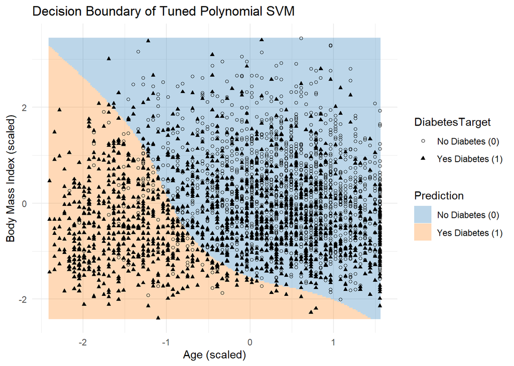

```r
# 1. Train data: AGE and BMICALC
plot_data <- train_data %>%
  select(Age = AGE, BMI = BMICALC, DiabetesTarget) %>%
  mutate(DiabetesTarget = factor(DiabetesTarget))

# 2. Scale
scaled_Age <- scale(plot_data$Age)
scaled_BMI <- scale(plot_data$BMI)

plot_data$Age <- as.numeric(scaled_Age)
plot_data$BMI <- as.numeric(scaled_BMI)

# 3. Tuned Polynomial SVM model
set.seed(123)
tuned_poly__best2variables <- tune(
  svm,
  DiabetesTarget ~ Age + BMI,
  data = plot_data,
  kernel = "polynomial",
  ranges = list(cost = c(0.1, 1, 10), degree = c(2, 3, 4)),
  scale = FALSE
)$best.model

# 4. Grid to visualize the decision surface
x_range <- seq(min(plot_data$Age), max(plot_data$Age), length.out = 200)
y_range <- seq(min(plot_data$BMI), max(plot_data$BMI), length.out = 200)
grid <- expand.grid(Age = x_range, BMI = y_range)
grid$pred <- predict(tuned_poly__best2variables, newdata = grid)

# 5. Decision boundary plot
ggplot() +
  geom_tile(data = grid, aes(x = Age, y = BMI, fill = pred), alpha = 0.3) +
  scale_fill_manual(
    values = c("0" = "#1f77b4", "1" = "#ff7f0e"),
    name = "Prediction",
    labels = c("No Diabetes (0)", "Yes Diabetes (1)")
  ) +
  geom_point(data = plot_data, aes(x = Age, y = BMI, shape = DiabetesTarget), color = "black", size = 1.3) +
  scale_shape_manual(
    values = c(1, 17),
    labels = c("No Diabetes (0)", "Yes Diabetes (1)")
  ) +
  labs(
    title = "Decision Boundary of Tuned Polynomial SVM",
    x = "Age (scaled)",
    y = "Body Mass Index (scaled)"
  ) +
  theme_minimal() +
  theme(legend.position = "right")
```

```r
# 6. Scale the test data
test_plot_data <- test_data %>%
  select(Age = AGE, BMI = BMICALC, DiabetesTarget) %>%
  mutate(DiabetesTarget = factor(DiabetesTarget))

test_plot_data$Age <- scale(
  test_plot_data$Age,
  center = attr(scaled_Age, "scaled:center"),
  scale = attr(scaled_Age, "scaled:scale")
)[, 1]

test_plot_data$BMI <- scale(
  test_plot_data$BMI,
  center = attr(scaled_BMI, "scaled:center"),
  scale = attr(scaled_BMI, "scaled:scale")
)[, 1]

# 7. Predict on test set
test_pred_poly <- predict(tuned_poly__best2variables, newdata = test_plot_data)

# 8. Accuracy
test_accuracy_poly <- mean(test_pred_poly == test_plot_data$DiabetesTarget)

# 9. Result
cat(sprintf("Test Accuracy of Tuned Polynomial SVM: %.4f\n", test_accuracy_poly))
```

```
## Test Accuracy of Tuned Polynomial SVM: 0.6726
```

Result: This decision boundary of the tuned Polynomial SVM effectively captures nonlinear relationships between age and body mass index in classifying diabetes. With a test accuracy of 67.3%, the model shows moderate predictive performance.

# 5. Performance Evaluation of the Best SVM Models: Tuned Linear SVM, Tuned Radial SVM, and Tuned Polynomial SVM

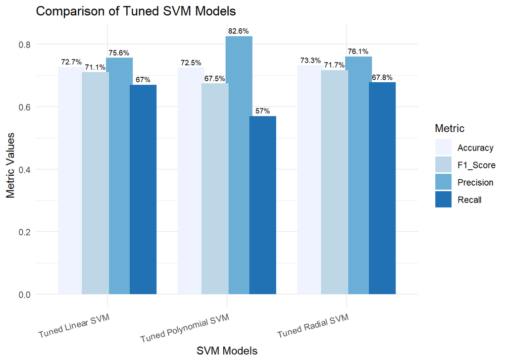

```r
# Create data
tuned_svm_metrics <- data.frame(
  Model = rep(c("Tuned Linear SVM", "Tuned Radial SVM", "Tuned Polynomial SVM"), each = 4),
  Metric = rep(c("Accuracy", "Precision", "Recall", "F1_Score"), times = 3),
  Value = c(
    0.7273, 0.7565, 0.6703, 0.7108,   # Linear
    0.7327, 0.7612, 0.6780, 0.7172,   # Radial
    0.7250, 0.8259, 0.5701, 0.6746   # Polynomial
  )
)

# Plot
ggplot(tuned_svm_metrics, aes(x = Model, y = Value, fill = Metric)) +
  geom_bar(stat = "identity", position = position_dodge(width = 0.8)) +
  geom_text(aes(label = paste0(round(Value * 100, 1), "%")),
            position = position_dodge(width = 0.8),
            vjust = -0.5, size = 2.5) +
  labs(
    title = "Comparison of Tuned SVM Models",
    x = "SVM Models",
    y = "Metric Values"
  ) +
  scale_fill_brewer(palette = "Blues") +
  theme_minimal() +
  theme(axis.text.x = element_text(angle = 15, hjust = 1))
```

Result: In the overall performance of the tuned SVM models: The Radial SVM achieved the best results, with the highest accuracy (73.3%), F1-score (71.7%), and strong recall (67.8%), making it the most effective at identifying individuals with diabetes. The Linear SVM performed consistently across all metrics with good generalization. The Polynomial SVM, despite its high precision (82.6%), showed the lowest recall, indicating a higher risk of missing diabetic cases.